# Aggregate data for density plots

When doing descriptive stats it’s quite useful to draw some histograms. A nice approach to that are the density plots that you can draw with `ggplot2::geom_density`. It is also useful to create a grid of plots by different subsets of data with `ggplot2::facet_grid`.

Let’s create some data to show it

```r
library(dplyr)
library(ggplot2)
library(knitr)
```

```r
simulator <- function(n) {
  t <- tibble(
    x = c(rnorm(n = n/2, 0, 1), rnorm(n = n, 2, 2), rnorm(n = n, 2, 3)),
    y = as.factor(c(rep("A", n/2), rep("B", n), rep("C", n))),
    z = as.factor(rbinom(n * 2.5, size = 1, prob = 0.5)),
    w = as.factor(sample(1:5, replace = TRUE, prob = rep(0.2, 5), size = n * 2.5))
  )
  return(t)
}
t <- simulator(1e5)
glimpse(t)
```

```
Observations: 250,000
Variables: 4
$ x <dbl> -0.005630142, -1.556907136, 0.518238210, 2.608738106, -0.938611152, -0.320382261, 0.085025367, 1.211191873, -0.023935085, 1.894575770, -0.092640139, -0.408570206, -0.177830465, -0.445829173...
$ y <fct> A, A, A, A, A, A, A, A, A, A, A, A, A, A, A, A, A, A, A, A, A, A, A, A, A, A, A, A, A, A, A, A, A, A, A, A, A, A, A, A, A, A, A, A, A, A, A, A, A, A, A, A, A, A, A, A, A, A, A, A, A, A, A, ...
$ z <fct> 0, 1, 0, 1, 1, 1, 1, 1, 0, 1, 0, 1, 1, 1, 0, 0, 0, 0, 1, 0, 0, 1, 1, 1, 1, 0, 0, 1, 0, 1, 0, 1, 1, 0, 1, 0, 0, 1, 0, 1, 1, 0, 1, 1, 1, 1, 0, 0, 1, 0, 0, 1, 1, 1, 1, 0, 1, 0, 1, 0, 0, 0, 1, ...
$ w <fct> 5, 1, 4, 2, 5, 5, 4, 5, 4, 5, 2, 2, 5, 3, 3, 4, 4, 2, 4, 2, 1, 3, 4, 5, 5, 3, 5, 2, 3, 4, 4, 3, 5, 1, 3, 3, 4, 1, 5, 1, 1, 5, 1, 3, 1, 2, 4, 1, 5, 3, 3, 2, 2, 4, 3, 5, 4, 5, 1, 5, 1, 1, 5, ...
```

```r
summary(t)
```

```
       x             y          z          w
 Min.   :-10.53256   A: 50000   0:125006   1:50330
 1st Qu.: -0.09163   B:100000   1:124994   2:49865
 Median :  1.36807   C:100000              3:50069
 Mean   :  1.59706                         4:50039
 3rd Qu.:  3.17779                         5:49697
 Max.   : 13.97121
```

and then let’s plot it

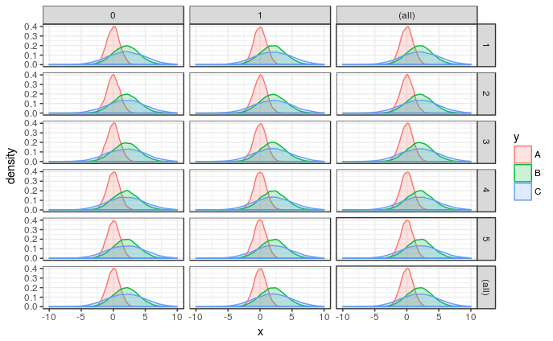

```r
t %>%
  ggplot(aes(x = x, colour = y, fill = y)) +
    geom_density(alpha = 0.2, adjust = 1) +
    xlim(c(-10, 10)) +
    theme_bw() +
    facet_grid(w ~ z,
               margins = TRUE,
               as.table = TRUE)
```

another plot that is nice to see…

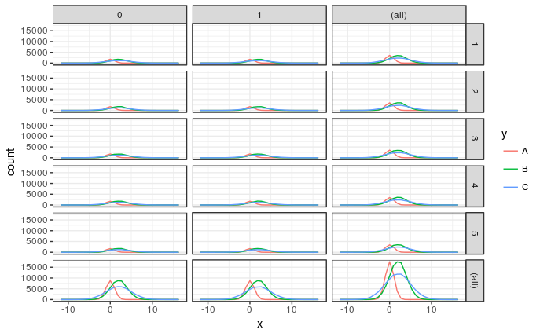

```r
t %>%
  ggplot(aes(x, colour = y, fill = y)) +
    geom_freqpoly() +
    theme_bw() +
    facet_grid(w ~ z,
               margins = TRUE)
```

However, if the data is a bit large, e.g. 10 million records or more, R chokes.

```r
t <- simulator(1e7)

t %>%
  ggplot(aes(x = x, colour = y, fill = y)) +
    geom_density(alpha = 0.2, adjust = 1) +
    xlim(c(-10, 10)) +
    theme_bw() +
    facet_grid(w ~ z,
               margins = TRUE,
               as.table = TRUE)
```

```
Error: cannot allocate vector of size 762.9 Mb
```

A solution to that is to aggregate the data before drawing the plots. Of course, there will be information loss, but that should be ok if the aggregation is done properly.

This is the first attempt to do an aggregation. Initially focusing on drawing a simple density plot for all the data.

I took the mean within each decile.

```r
nt <-
  t %>%
    mutate(parts = case_when(
      x < quantile(x, probs = 0.1) ~ 1,
      x < quantile(x, probs = 0.2) ~ 2,
      x < quantile(x, probs = 0.3) ~ 3,
      x < quantile(x, probs = 0.4) ~ 4,
      x < quantile(x, probs = 0.5) ~ 5,
      x < quantile(x, probs = 0.6) ~ 6,
      x < quantile(x, probs = 0.7) ~ 7,
      x < quantile(x, probs = 0.8) ~ 8,
      x < quantile(x, probs = 0.9) ~ 9,
      x <= quantile(x, probs = 1) ~ 10))
agg <-
  nt %>%
    group_by(parts, y) %>%
    summarise(s = mean(x))
```

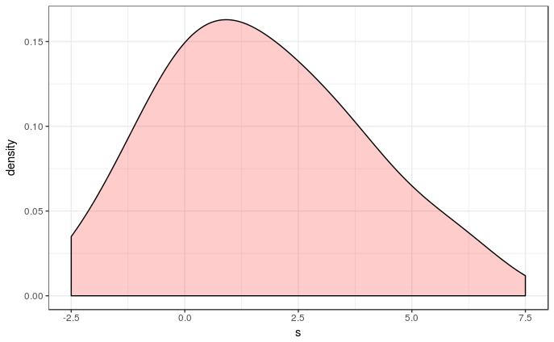

```r
agg %>%
  ggplot(aes(x = s)) +
    geom_density(alpha = 0.2,
                 adjust = 1,
                 fill = "red") +
    xlim(c(-2.5, 7.5)) +
    theme_bw()
```

Which is a bit different to the original

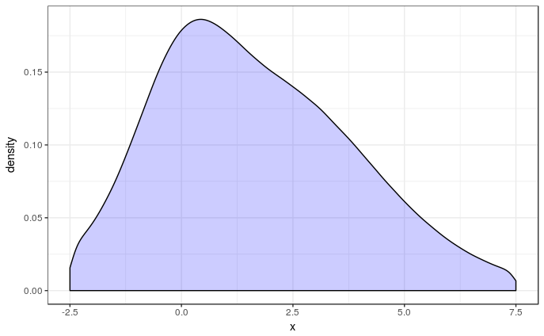

```r
t %>%
  ggplot(aes(x = x)) +
    geom_density(alpha = 0.2,
                 adjust = 2,
                 fill = "blue") +
    xlim(c(-2.5, 7.5)) +
    theme_bw()
```

The quantilisation is ugly and difficult to adjust if I want more precision. This option is a bit better becausee it by moving the `by` I can adjust it.

Here instead of taking the mean I’m taking the percentile value.

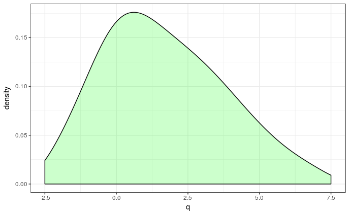

```r
qx <- tibble(q = quantile(t$x, probs = seq(0, 1, by = 0.0001)))
qx %>%
  ggplot(aes(x = q)) +
    geom_density(alpha = 0.2,
                 adjust = 2,
                 fill = "green") +
    xlim(c(-2.5, 7.5)) +
    theme_bw()
```

This option is fast enough, so we can now expand it to using one grouping variable.

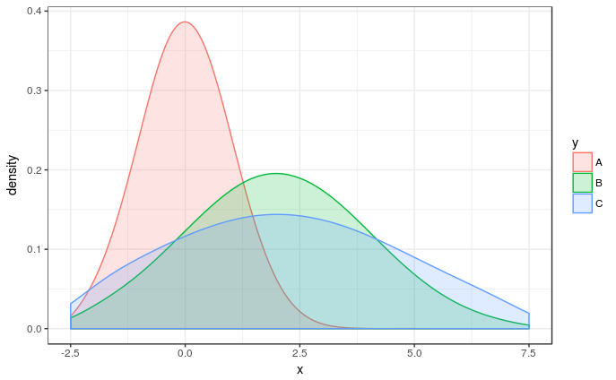

```r
library(tidyr)
library(broom)
library(purrr)
qx <-
  t %>%
    nest(-y) %>%
    mutate(Quantiles = map(data, ~ quantile(.$x, probs = seq(0, 1, by = 0.0001)))) %>%
    unnest(map(Quantiles, tidy))
qx %>%
  ggplot(aes(x = x, colour = y, fill = y)) +
    geom_density(alpha = 0.2,
                 adjust = 2) +
    xlim(c(-2.5, 7.5)) +
    theme_bw()
```

Which looks extremely similar to the original one:

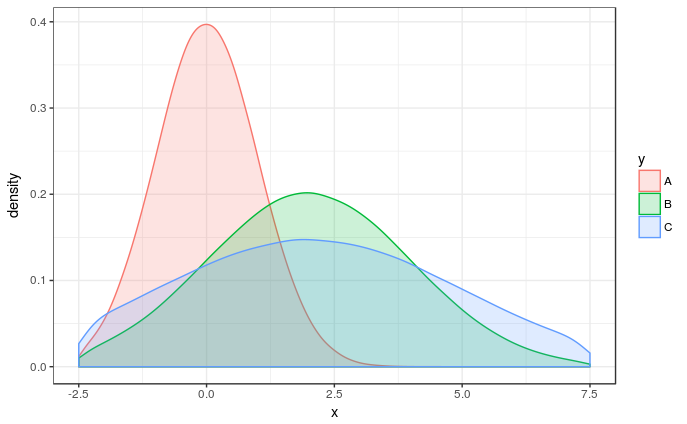

```r
t %>%
  ggplot(aes(x = x, colour = y, fill = y)) +
    geom_density(alpha = 0.2,
                 adjust = 2) +
    xlim(c(-2.5, 7.5)) +
    theme_bw()
```

And adding in the `facet_grid` it still runs fast and the plots look very very similar to what they would look like using the original data.

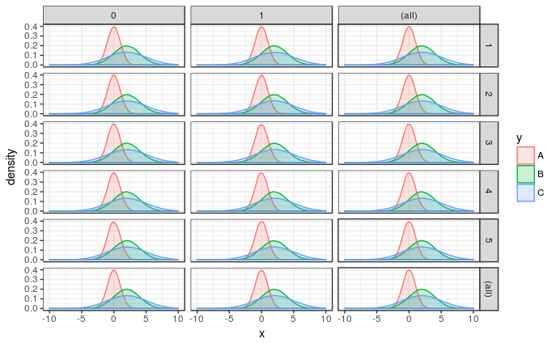

```r
qx <-
  t %>%
    nest(-y,
         -w,
         -z) %>%
    mutate(Quantiles = map(data, ~ quantile(.$x, probs = seq(0, 1, by = 0.0001)))) %>%
    unnest(map(Quantiles, tidy))
qx %>%
  ggplot(aes(x = x, colour = y, fill = y)) +
    geom_density(alpha = 0.2, adjust = 1) +
    xlim(c(-10, 10)) +
    theme_bw() +
    facet_grid(w ~ z,
               margins = TRUE)
```

```r
p
```

[output not shown]

As always stackoverflow crowd provided 90% of [the solution](https://stackoverflow.com/questions/30488389/using-dplyr-window-functions-to-calculate-percentiles).